# Metropolis-Kimura Evolutionary Dynamics

Author

Affiliation

Manuel Razo-Mejia

Department of Biology, Stanford University

Keywords

evolutionary dynamics, fitness landscape, genotype-phenotype density, Metropolis-Hastings, population genetics

```julia
# Import project package
import Antibiotic

# Import basic math libraries
import StatsBase
import LinearAlgebra
import Random
import Distributions

# Load CairoMakie for plotting
using CairoMakie
import ColorSchemes

# Activate backend
CairoMakie.activate!()

# Set custom plotting style
Antibiotic.viz.theme_makie!()
```

# Evolutionary dynamics on a fitness and genotype-phenotype density landscape

In this notebook we will explore a simple model of evolution on a fitness landscape with an explicit genotype-phenotype density function.

The setting is the following:

Let $\underline{x}(t) = (x_1(t), x_2(t), \cdots, x_N(t))$ be an $N$ dimensional vector of phenotypes at time $t$. The fitness for a given environment $E$ is a scalar function $F_E(\underline{x})$ such that
$$F_E: \mathbb{R}^N \to \mathbb{R},
\tag{1}$$

i.e, the coordinates in phenotype space map to a fitness value. As a particular fitness function we will consider a series of Gaussian fitness peaks,

$$F_E(\underline{x}) =
\sum_{p=1}^P A_p
\exp\left(
-\frac{1}{2}
(\underline{x} - \underline{\hat{x}}^{(p)})^T
\Sigma_p^{-1}
(\underline{x} - \underline{\hat{x}}^{(p)})
\right),
\tag{2}$$

where $P$ is the number of peaks, $A_p$ is the amplitude of the $p$-th peak, $\underline{\hat{x}}^{(p)}$ is the $N$-dimensional vector of optimal phenotypes for the $p$-th peak, and $\Sigma_p$ is the $N \times N$ covariance matrix for the $p$-th peak. This formulation allows for multiple peaks in the fitness landscape, each potentially having different heights, widths, and covariance structures between dimensions. The covariance matrix $\Sigma_p$ captures potential interactions between different phenotypic dimensions, allowing for more complex and realistic fitness landscapes.

In the same vein, we define a genotype-phenotype density map $GP(\underline{x})$ as a scalar function that maps a phenotype to a number related to the probability of sampling a given phenotype, i.e.,

$$GP: \mathbb{R}^N \to \mathbb{R},
\tag{3}$$

where $GP(\underline{x})$ is related to the probability of a genotype mapping to a phenotype $\underline{x}$. As a particular genotype-phenotype density function we will consider a set of negative Gaussian peaks that will serve as “mutational barriers” that limit the range of phenotypes that can be reached. The deeper the peak, the more difficult it is to reach the phenotype associated with that peak. This idea is captured by the following genotype-phenotype density function:

$$GP(\underline{x}) =
\sum_{p=1}^P -B_p
\exp\left(
-\frac{1}{2}(\underline{x} - \underline{\hat{x}}^{(p)})^T
\Sigma_p^{-1}
(\underline{x} - \underline{\hat{x}}^{(p)})
\right),
\tag{4}$$

where $B_p$ is the depth of the $p$-th peak, and $\underline{\hat{x}}^{(p)}$ is the $N$-dimensional vector of optimal phenotypes for the $p$-th peak.

Both, the fitness landscape and the genotype-phenotype density function are built on Gaussian functions. Let’s therefore define a `struct` to hold the parameters of a single peak.

```julia
@doc raw"""
    GaussianPeak

A struct to hold the parameters of a single Gaussian peak.

# Fields
- `amplitude::AbstractFloat`: The amplitude of the peak.
- `mean::AbstractVector`: The mean of the peak.
- `covariance::AbstractMatrix`: The covariance matrix of the peak.
"""
struct GaussianPeak
    amplitude::AbstractFloat
    mean::AbstractVector
    covariance::AbstractMatrix
end
```

Next, let’s define a function to evaluate the fitness landscape at a given phenotype.

```julia
@doc raw"""
    fitness(peak::GaussianPeak, x::AbstractVecOrMat; min_value::AbstractFloat=0.0)
    fitness(peaks::Vector{GaussianPeak}, x::AbstractVecOrMat; min_value::AbstractFloat=0.0)

Calculate the fitness value for a given phenotype `x` based on Gaussian peak(s).

# Arguments
- `peak::GaussianPeak`: A single Gaussian peak.
- `peaks::Vector{GaussianPeak}`: A vector of Gaussian peaks.
- `x::AbstractVecOrMat`: The phenotype(s) for which to calculate the fitness.
  Can be a vector for a single phenotype or a matrix for multiple phenotypes,
  where each column corresponds to a phenotype.
- `min_value::AbstractFloat=1.0`: The minimum fitness value to be added to the
  Gaussian contribution.

# Returns
The calculated fitness value(s).

# Description
The first method computes the fitness for a single Gaussian peak, while the
second method computes the sum of fitness values for multiple Gaussian peaks. In
both cases, the `min_value` is added to the Gaussian contribution to ensure a
minimum fitness level.
"""
function fitness(
    peak::GaussianPeak, x::AbstractVecOrMat; min_value::AbstractFloat=1.0
)
    # Calculate the Gaussian peak
    gaussian = peak.amplitude * exp(
        -0.5 *
        (x - peak.mean)' *
        LinearAlgebra.inv(peak.covariance) *
        (x - peak.mean)
    )
    # Return the fitness by shifting the Gaussian peak by the minimum value
    return gaussian + min_value
end

function fitness(
    peaks::Vector{GaussianPeak},
    x::AbstractVecOrMat;
    min_value::AbstractFloat=1.0
)
    # Sum the Gaussian contributions from all peaks
    total_gaussian = sum(
        peak.amplitude *
        exp(
            -0.5 *
            (x - peak.mean)' *
            LinearAlgebra.inv(peak.covariance) *
            (x - peak.mean)
        )
        for peak in peaks
    )
    # Return the fitness by shifting the Gaussian peak by the minimum value
    return total_gaussian + min_value
end
```

Let’s test the fitness function with a single Gaussian peak.

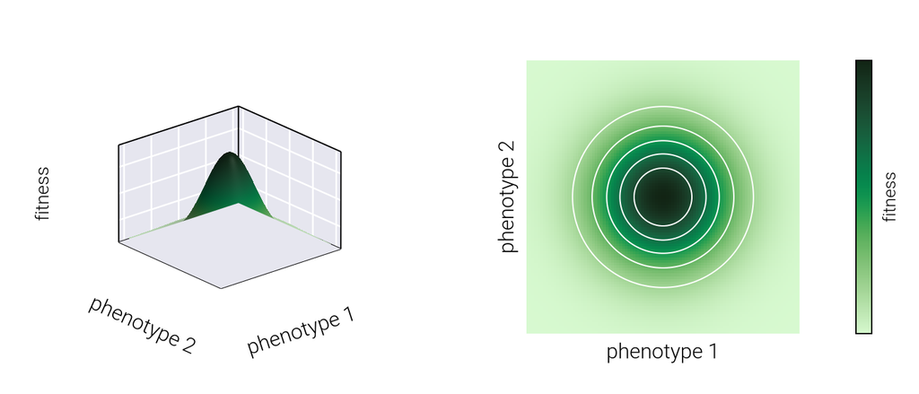

```julia
# Define peak parameters
amplitude = 1.0
mean = [0.0, 0.0]
covariance = [0.5 0.0; 0.0 0.5]

# Create peak
fit_peak = GaussianPeak(amplitude, mean, covariance)

# Define range of phenotypes to evaluate
x = range(-2, 2, length=100)
y = range(-2, 2, length=100)

# Create meshgrid
F = fitness.(Ref(fit_peak), [[x, y] for x in x, y in y])

# Initialize figure
fig = Figure(size=(700, 300))

# Add axis for 3D plot
ax3 = Axis3(
    fig[1, 1],
    xlabel="phenotype 1",
    ylabel="phenotype 2",
    zlabel="fitness",
    yticklabelsvisible=false,
    xticklabelsvisible=false,
    zticklabelsvisible=false,
)

# Add axis for contour plot
ax2 = Axis(
    fig[1, 2],
    xlabel="phenotype 1",
    ylabel="phenotype 2",
    aspect=AxisAspect(1),
    yticklabelsvisible=false,
    xticklabelsvisible=false,
)

# Plot fitness landscape
surface!(ax3, x, y, F, color=F, colormap=:algae)

# Plot a heatmap of the fitness landscape
hm = heatmap!(ax2, x, y, F, colormap=:algae)

# Add a colorbar
Colorbar(
    fig[1, 3],
    hm,
    label="fitness",
    labelsize=13,
    height=Relative(1),
    ticksvisible=false,
    ticklabelsvisible=false
)
# Plot contour plot
contour!(ax2, x, y, F, color=:white)

fig
```

Next, let’s define a function to evaluate the genotype-phenotype density function at a given phenotype.

```julia
@doc raw"""
    genotype_phenotype_density(
        peak::Union{GaussianPeak, Vector{GaussianPeak}},
        x::AbstractVecOrMat;
        max_value::Float64 = 1.0
    )

Calculate the genotype-phenotype density value for a given phenotype `x` based
on Gaussian peak(s).

# Arguments
- `peak::Union{GaussianPeak, Vector{GaussianPeak}}`: A single Gaussian peak or a
  vector of Gaussian peaks.
- `x::AbstractVecOrMat`: The phenotype(s) for which to calculate the genotype-
  phenotype density. Can be a vector for a single phenotype or a matrix for
  multiple phenotypes, where each column corresponds to a phenotype.
- `max_value::Float64`: Optional. The maximum value of the genotype-phenotype
  density. Default is 1.0.
  1.0.

# Returns
The calculated genotype-phenotype density value(s).
"""
function genotype_phenotype_density(
    peak::GaussianPeak, x::AbstractVecOrMat; max_value::AbstractFloat=1.0
)
    # Calculate the Gaussian peak
    gaussian = peak.amplitude * exp(
        -0.5 *
        (x - peak.mean)' *
        LinearAlgebra.inv(peak.covariance) *
        (x - peak.mean)
    )
    # Return the genotype-phenotype density by inverting the Gaussian peak
    # shifted by the maximum value
    return -(gaussian - max_value)
end

function genotype_phenotype_density(
    peaks::Vector{GaussianPeak},
    x::AbstractVecOrMat;
    max_value::AbstractFloat=1.0
)
    # Sum the Gaussian contributions from all peaks
    total_gaussian = sum(
        peak.amplitude *
        exp(
            -0.5 *
            (x - peak.mean)' *
            LinearAlgebra.inv(peak.covariance) *
            (x - peak.mean)
        )
        for peak in peaks
    )
    # Return the genotype-phenotype density by inverting the Gaussian peak
    # shifted by the maximum value
    return -(total_gaussian - max_value)
end
```

Let’s test the genotype-phenotype density function with four Gaussian peaks in the corners of a square in phenotype space.

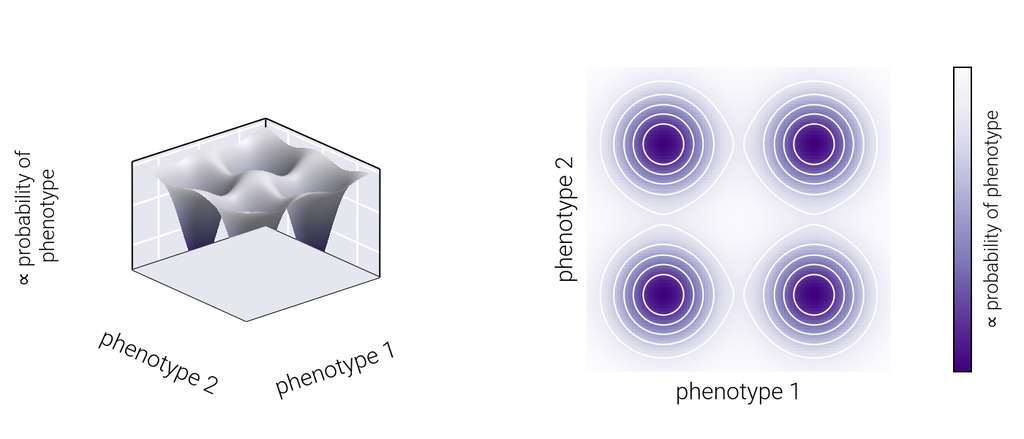

```julia
# Define peak parameters
amplitude = 0.5
means = [
    [-1.5, -1.5],
    [1.5, -1.5],
    [1.5, 1.5],
    [-1.5, 1.5],
]
covariance = [0.45 0.0; 0.0 0.45]

# Create peak
mut_peaks = GaussianPeak.(Ref(amplitude), means, Ref(covariance))

# Define range of phenotypes to evaluate
x = range(-3, 3, length=100)
y = range(-3, 3, length=100)

# Create meshgrid
M = genotype_phenotype_density.(Ref(mut_peaks), [[x, y] for x in x, y in y])

# Initialize figure
fig = Figure(size=(700, 300))

# Add axis for 3D plot
ax3 = Axis3(
    fig[1, 1],
    xlabel="phenotype 1",
    ylabel="phenotype 2",
    zlabel="∝ probability of \nphenotype",
    yticklabelsvisible=false,
    xticklabelsvisible=false,
    zticklabelsvisible=false,
)

# Add axis for contour plot
ax2 = Axis(
    fig[1, 2],
    xlabel="phenotype 1",
    ylabel="phenotype 2",
    aspect=AxisAspect(1),
    yticklabelsvisible=false,
    xticklabelsvisible=false,
)

# Plot genotype-phenotype density
surface!(ax3, x, y, M, color=M, colormap=Reverse(ColorSchemes.Purples_9))

# Plot a heatmap of the genotype-phenotype density
hm = heatmap!(ax2, x, y, M, colormap=Reverse(ColorSchemes.Purples_9))

# Add a colorbar
Colorbar(
    fig[1, 3],
    hm,
    label="∝ probability of phenotype",
    labelsize=13,
    height=Relative(1),
    ticksvisible=false,
    ticklabelsvisible=false
)

# Plot contour plot
contour!(ax2, x, y, M, color=:white)

fig
```

## Evolutionary dynamics

### Metropolis-Kimura Algorithm in Evolutionary Dynamics

We now introduce a biologically motivated algorithm that combines elements of the Metropolis-Hastings algorithm with Motoo Kimura’s population genetics theory. This approach implements a two-step process that separately models:

1. The probability of mutation occurring (mutation accessibility) as governed by the genotype-phenotype density.
2. The probability of fixation within a population (selection) determined by the fitness effect of such mutation and the effective population size.

### Biological Motivation

In natural populations, evolution proceeds through two distinct processes:

1. **Mutation**: New variants arise through random genetic changes. The probability of specific mutations depends on molecular mechanisms and constraints of the genotype-phenotype map.
2. **Fixation**: Once a mutation occurs, it must spread through the population to become fixed. The probability of fixation depends on the selection coefficient (fitness advantage) and the effective population size.

### Mathematical Framework

#### Mutation Probability

The probability of a mutation from phenotype $\underline{x}$ to $\underline{x}'$ is modeled using a Metropolis-like criterion based on the genotype-phenotype density:

$$\pi_{\text{mut}}(\underline{x} \to \underline{x}') =
\min\left(1, \frac{GP(\underline{x}')}{GP(\underline{x})}\right)^{\beta}
\tag{5}$$

Here, $GP(\underline{x})$ represents the genotype-phenotype density at phenotype $\underline{x}$, and $\beta$ is a parameter controlling the strength of mutational constraints. The higher $\beta$ is, the less likely a mutation going downhill in genotype-phenotype density is to be accepted.

#### Kimura’s Fixation Probability

Once a mutation occurs, its probability of fixation in a population of effective size $N$ is given by Kimura’s formula

$$\pi_{\text{fix}}(\underline{x} \to \underline{x}') =
\frac{1 - e^{-2s}}{1 - e^{-2Ns}}
\tag{6}$$

where $s$ is the selection coefficient. We compute this selection coefficient as the difference in fitness between the new and old phenotype divided by the fitness of the old phenotype, i.e.,

$$s = \frac{F_E(\underline{x}') - F_E(\underline{x})}{F_E(\underline{x})}
\tag{7}$$

This equation captures a fundamental result from population genetics: beneficial mutations ($s > 0$) have a higher probability of fixation, with the probability approaching $2s$ for small positive selection coefficients and approaching 1 for large positive selection coefficients. Deleterious mutations ($s < 0$) have an exponentially decreasing probability of fixation as population size increases.

#### Overall Acceptance Probability of Mutation

The overall acceptance probability—defined as the probability of a proposed step $x \rightarrow x'$—is the product of the mutation probability and the fixation probability

$$\pi_{\text{accept}}(\underline{x} \to \underline{x}') =
\pi_{\text{mut}}(\underline{x} \to \underline{x}') \cdot
\pi_{\text{fix}}(\underline{x} \to \underline{x}')
\tag{8}$$

This two-step process better reflects the biological reality of evolution, where both mutational accessibility and selection contribute to evolutionary trajectories.

### Numerical Implementation

Let’s now implement the Metropolis-Kimura algorithm in code.

```julia
@doc raw"""
    evo_metropolis_kimura(x0, fitness_peaks, gen_peaks, N, β, µ, n_steps)

Perform evolutionary algorithm to simulate phenotypic evolution using a
Metropolis-Hastings-like mutation probability and Kimura's fixation probability.

# Arguments
- `x0::AbstractVector`: Initial phenotype vector.
- `fitness_peaks::Union{GaussianPeak, Vector{GaussianPeak}}`: Fitness landscape
  defined by one or more Gaussian peaks.
- `gen_peaks::Union{GaussianPeak, Vector{GaussianPeak}}`: Genotype-phenotype
  density landscape defined by one or more Gaussian peaks.
- `N::Real`: Effective population size.
- `β::Real`: Parameter controlling the strength of mutational constraints.
- `µ::Real`: Mutation step size standard deviation.
- `n_steps::Int`: Number of steps to simulate.

# Returns
- `Matrix{Float64}`: Matrix of phenotypes, where each column represents a step
  in the simulation.

# Description
This function implements a two-step evolutionary algorithm to simulate
phenotypic evolution in a landscape defined by fitness and genotype-phenotype
density. It uses the following steps:

1. Initialize the phenotype trajectory with the given starting point.
2. For each step:
   a. Propose a new phenotype by adding Gaussian noise.
   b. Calculate the fitness and genotype-phenotype density values for the new
      phenotype.
   c. Compute the mutation probability P_mut = min(1, (GP(x_new)/GP(x))^β)
   d. Compute the selection coefficient s = (F_new - F)/F
   e. Calculate fixation probability using Kimura's equation:
      P_fix = (1 - exp(-2s))/(1 - exp(-2Ns))
   f. Accept or reject based on P_accept = P_mut * P_fix
3. Return the complete phenotype trajectory.
"""
function evo_metropolis_kimura(
    x0::AbstractVector,
    fitness_peaks::Union{GaussianPeak,Vector{GaussianPeak}},
    gen_peaks::Union{GaussianPeak,Vector{GaussianPeak}},
    N::Real,
    β::Real,
    µ::Real,
    n_steps::Int,
)
    # Initialize array to hold phenotypes
    x = Matrix{Float64}(undef, length(x0), n_steps + 1)
    # Set initial phenotype
    x[:, 1] = x0

    # Compute fitness and genotype-phenotype density at initial phenotype
    fitness_val = fitness(fitness_peaks, x0)
    gen_val = genotype_phenotype_density(gen_peaks, x0)

    # Loop over steps
    for t in 1:n_steps
        # Propose new phenotype
        x_new = x[:, t] + µ * randn(length(x0))

        # Calculate fitness and genotype-phenotype density
        fitness_val_new = fitness(fitness_peaks, x_new)
        gen_val_new = genotype_phenotype_density(gen_peaks, x_new)

        # Compute selection coefficient
        s = (fitness_val_new - fitness_val) /
            (fitness_val + eps(eltype(fitness_val)))

        # Compute mutation probability
        P_mut = min(1, (gen_val_new / gen_val)^β)

        # Compute fixation probability using Kimura's equation
        # Use approximation when s is very small for numerical stability
        if abs(s) < 1e-10
            P_fix = 1 / N
        elseif abs(s) < 0.1
            # For small s, use approximation
            P_fix = (1 - exp(-2 * s)) / (1 - exp(-2 * N * s))
            # Check for potential numerical issues
            if !isfinite(P_fix) || P_fix < 0
                P_fix = s > 0 ? 2 * s : 1 / N
            end
        else
            # Otherwise use full Kimura equation
            P_fix = (1 - exp(-2 * s)) / (1 - exp(-2 * N * s))
        end

        # Compute acceptance probability
        P_accept = P_mut * P_fix

        # Accept or reject proposal
        if rand() < P_accept
            # Accept proposal
            x[:, t+1] = x_new
            # Update fitness and genotype-phenotype density
            fitness_val = fitness_val_new
            gen_val = gen_val_new
        else
            # Reject proposal
            x[:, t+1] = x[:, t]
        end
    end # for
    return x
end # function
```

Let’s test this function with the previously defined fitness and genotype-phenotype density functions.

```julia
Random.seed!(42)

# Define peak parameters
amplitude = 5.0
mean = [0.0, 0.0]
covariance = [3.0 0.0; 0.0 3.0]
# Create peak
fit_peak = GaussianPeak(amplitude, mean, covariance)
# Define peak parameters
amplitude = 1.0
means = [
    [-1.5, -1.5],
    [1.5, -1.5],
    [1.5, 1.5],
    [-1.5, 1.5],
]
covariance = [0.45 0.0; 0.0 0.45]

# Create peak
mut_peaks = GaussianPeak.(Ref(amplitude), means, Ref(covariance))

# Set initial phenotype
x0 = [-2.5, -2.5]

# Set parameters
N = 10 # Effective population size
β = 10.0    # Mutational constraint parameter
µ = 0.1    # Mutation step size
n_steps = 3000

# Run Metropolis-Kimura algorithm
x_traj = evo_metropolis_kimura(x0, fit_peak, mut_peaks, N, β, µ, n_steps)
```

Let’s plot the trajectory of the phenotypes in phenotype space.

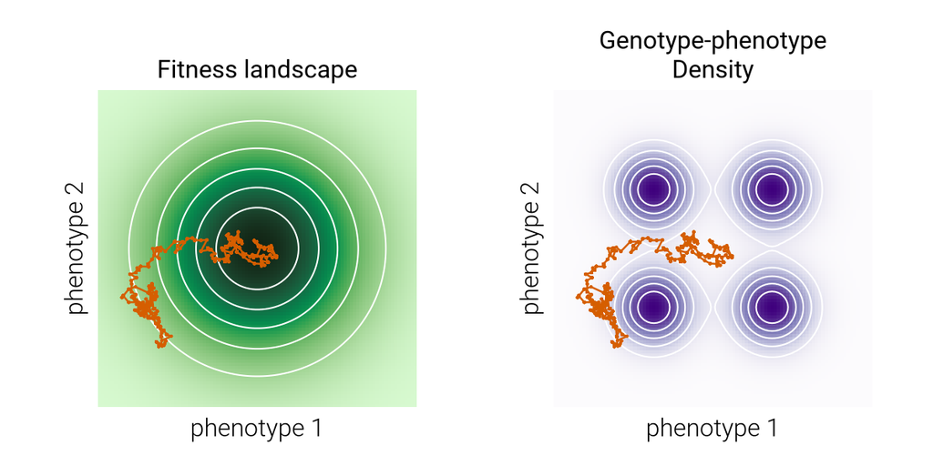

```julia
Random.seed!(42)

# Define range of phenotypes to evaluate
x = range(-4, 4, length=100)
y = range(-4, 4, length=100)

# Create meshgrid
F = fitness.(Ref(fit_peak), [[x, y] for x in x, y in y])
M = genotype_phenotype_density.(Ref(mut_peaks), [[x, y] for x in x, y in y])

# Initialize figure
fig = Figure(size=(600, 300))

# Add axis for trajectory in fitness landscape
ax1 = Axis(
    fig[1, 1],
    xlabel="phenotype 1",
    ylabel="phenotype 2",
    aspect=AxisAspect(1),
    title="Fitness landscape",
    yticklabelsvisible=false,
    xticklabelsvisible=false,
)
# Add axis for trajectory in genotype-phenotype density
ax2 = Axis(
    fig[1, 2],
    xlabel="phenotype 1",
    ylabel="phenotype 2",
    aspect=AxisAspect(1),
    title="Genotype-phenotype\nDensity",
    yticklabelsvisible=false,
    xticklabelsvisible=false,
)

# Plot a heatmap of the fitness landscape
heatmap!(ax1, x, y, F, colormap=:algae)
# Plot heatmap of genotype-phenotype density
heatmap!(ax2, x, y, M, colormap=Reverse(ColorSchemes.Purples_9))

# Plot contour plot
contour!(ax1, x, y, F, color=:white)
contour!(ax2, x, y, M, color=:white)

# Plot trajectory
scatterlines!.(
    [ax1, ax2],
    Ref(x_traj[1, :]),
    Ref(x_traj[2, :]),
    color=ColorSchemes.seaborn_colorblind[4],
    markersize=3
)

fig
```

We can see that the trajectory climbs the fitness peak, but it does so by avoiding regions of low genotype-phenotype density.

Let’s plot the fitness and the genotype-phenotype density for the phenotypes in the trajectory over time.

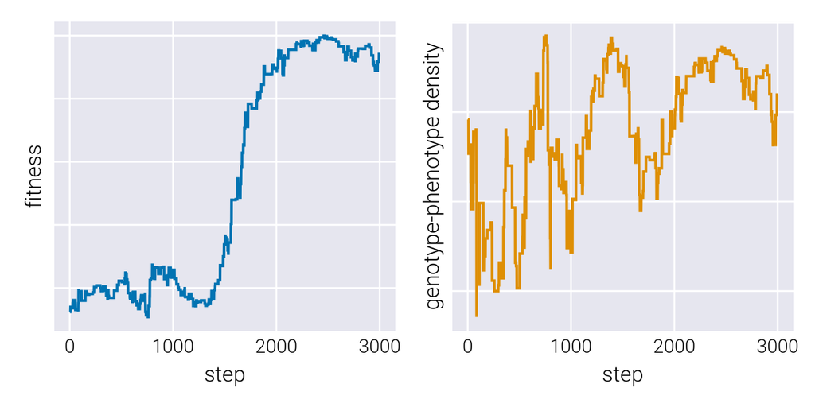

```julia
# Initialize arrays to hold fitness and genotype-phenotype density
F_traj = Vector{Float64}(undef, n_steps + 1)
M_traj = Vector{Float64}(undef, n_steps + 1)

# Loop over steps
for (i, x) in enumerate(eachcol(x_traj))
    F_traj[i] = fitness(fit_peak, x)
    M_traj[i] = genotype_phenotype_density(mut_peaks, x)
end

# Initialize figure
fig = Figure(size=(600, 300))

# Add axis for fitness
ax1 = Axis(
    fig[1, 1],
    xlabel="step",
    ylabel="fitness",
    yticklabelsvisible=false,
)

# Add axis for genotype-phenotype density
ax2 = Axis(
    fig[1, 2],
    xlabel="step",
    ylabel="genotype-phenotype density",
    yticklabelsvisible=false,
)

# Plot fitness
lines!(ax1, F_traj, color=ColorSchemes.seaborn_colorblind[1])

# Plot genotype-phenotype density
lines!(ax2, M_traj, color=ColorSchemes.seaborn_colorblind[2])

fig
```

Let’s now repeat the simulation multiple times and plot all different trajectories.

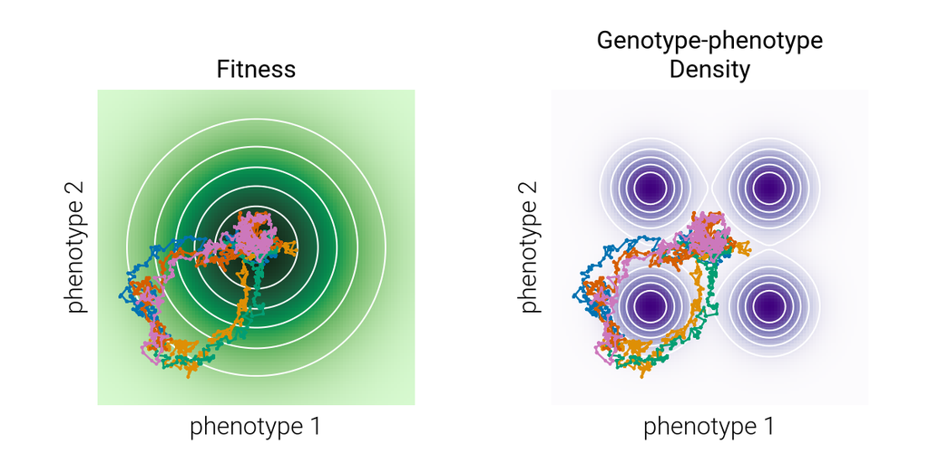

```julia
Random.seed!(42)

# Define number of simulations
n_sim = 5

# Run simulations
x_traj_list = [
    evo_metropolis_kimura(x0, fit_peak, mut_peaks, N, β, µ, n_steps)
    for _ in 1:n_sim
]

# Initialize figure
fig = Figure(size=(600, 300))

# Add axis for fitness landscape
ax1 = Axis(
    fig[1, 1],
    xlabel="phenotype 1",
    ylabel="phenotype 2",
    aspect=AxisAspect(1),
    title="Fitness",
    yticklabelsvisible=false,
    xticklabelsvisible=false,
)
# Add axis for genotype-phenotype density
ax2 = Axis(
    fig[1, 2],
    xlabel="phenotype 1",
    ylabel="phenotype 2",
    aspect=AxisAspect(1),
    title="Genotype-phenotype\nDensity",
    yticklabelsvisible=false,
    xticklabelsvisible=false,
)

# Plot fitness landscape
heatmap!(ax1, x, y, F, colormap=:algae)
# Plot heatmap of genotype-phenotype density
heatmap!(ax2, x, y, M, colormap=Reverse(ColorSchemes.Purples_9))

# Plot contour plot
contour!(ax1, x, y, F, color=:white)
contour!(ax2, x, y, M, color=:white)

# Loop over simulations
for (i, x_traj) in enumerate(x_traj_list)
    # Plot trajectory
    scatterlines!.(
        [ax1, ax2],
        Ref(x_traj[1, :]),
        Ref(x_traj[2, :]),
        color=ColorSchemes.seaborn_colorblind[i],
        markersize=3
    )
end

# Set limits
xlims!(ax1, -4, 4)
ylims!(ax1, -4, 4)
xlims!(ax2, -4, 4)
ylims!(ax2, -4, 4)

fig
```

## Conclusion

In this notebook, we developed a biologically-motivated model for evolutionary dynamics that combines elements of the Metropolis-Hastings algorithm with classic population genetics theory. This model implements a two-step process that separately accounts for:

1. The probability of mutation occurring (based on genotype-phenotype density)
2. The probability of fixation within a population (based on Kimura’s fixation probability)

By separating these processes, our *Metropolis-Kimura* algorithm provides a plausible model of evolutionary dynamics, where mutational constraints and selection pressures interact to shape evolutionary trajectories. This approach allows us to explore how both the accessibility of phenotypic space and the fitness landscape influence the paths taken by evolving populations.